# chap2.R

## Rank correlation (for ordinal features)

convert to ordinal variables with cut (see ? cut) into ordered factors with three levels

```r
iris_ord <- data.frame(
  cut(iris[,1], 3, labels=c("short", "medium", "long"), ordered=T),
  cut(iris[,2], 3, labels=c("short", "medium", "long"), ordered=T),
  cut(iris[,3], 3, labels=c("short", "medium", "long"), ordered=T),
  cut(iris[,4], 3, labels=c("short", "medium", "long"), ordered=T),
  iris[,5])
colnames(iris_ord) <- colnames(iris)
summary(iris_ord)
```

```
##  Sepal.Length Sepal.Width Petal.Length Petal.Width       Species
##  short :59    short :47   short :50    short :50   setosa    :50
##  medium:71    medium:88   medium:54    medium:54   versicolor:50
##  long  :20    long  :15   long  :46    long  :46   virginica :50
```

```r
head(iris_ord$Sepal.Length)
```

```
## [1] short short short short short short
## Levels: short < medium < long
```

Kendall’s tau rank correlation coefficient

```r
cor(sapply(iris_ord[,1:4], xtfrm), method="kendall")
```

```
##              Sepal.Length Sepal.Width Petal.Length Petal.Width
## Sepal.Length    1.0000000  -0.1437985    0.7418595   0.7295139
## Sepal.Width    -0.1437985   1.0000000   -0.3298796  -0.3154474
## Petal.Length    0.7418595  -0.3298796    1.0000000   0.9198290
## Petal.Width     0.7295139  -0.3154474    0.9198290   1.0000000
```

Spearman’s rho

```r
cor(sapply(iris_ord[,1:4], xtfrm), method="spearman")
```

```
##              Sepal.Length Sepal.Width Petal.Length Petal.Width
## Sepal.Length    1.0000000  -0.1569659    0.7937613   0.7843406
## Sepal.Width    -0.1569659   1.0000000   -0.3662775  -0.3517262
## Petal.Length    0.7937613  -0.3662775    1.0000000   0.9399038
## Petal.Width     0.7843406  -0.3517262    0.9399038   1.0000000
```

**Note:** unfortunately we have to transform the ordered factors into numbers representing the order with xtfrm first.

Compare to the Pearson correlation on the original data

```r
cor(iris[,1:4])
```

```
##              Sepal.Length Sepal.Width Petal.Length Petal.Width
## Sepal.Length    1.0000000  -0.1175698    0.8717538   0.8179411
## Sepal.Width    -0.1175698   1.0000000   -0.4284401  -0.3661259
## Petal.Length    0.8717538  -0.4284401    1.0000000   0.9628654
## Petal.Width     0.8179411  -0.3661259    0.9628654   1.0000000
```

## Relationship between nominal and ordinal features

Is sepal length and species related? Use cross tabulation

```r
tbl <- table(Sepal.Length=iris_ord$Sepal.Length, iris_ord$Species)
tbl
```

```
##
## Sepal.Length setosa versicolor virginica
##       short      47         11         1
##       medium      3         36        32
##       long        0          3        17
```

Test of Independence: Pearson’s chi-squared test is performed with the null hypothesis that the joint distribution of the cell counts in a 2-dimensional contingency table is the product of the row and column marginals. (h0 is independence)

```r
chisq.test(tbl)
```

```
##
##  Pearson's Chi-squared test
##
## data:  tbl
## X-squared = 111.63, df = 4, p-value < 2.2e-16
```

Using xtabs instead

```r
x <- xtabs(~Sepal.Length + Species, data=iris_ord)
x
```

```
##             Species
## Sepal.Length setosa versicolor virginica
##       short      47         11         1
##       medium      3         36        32
##       long        0          3        17
```

```r
summary(x)
```

```
## Call: xtabs(formula = ~Sepal.Length + Species, data = iris_ord)
## Number of cases in table: 150
## Number of factors: 2
## Test for independence of all factors:
##  Chisq = 111.63, df = 4, p-value = 3.262e-23
```

Groupwise averages

```r
aggregate(Sepal.Length ~ Species, data=iris, FUN = mean)
```

```
##      Species Sepal.Length
## 1     setosa        5.006
## 2 versicolor        5.936
## 3  virginica        6.588
```

```r
aggregate(Sepal.Width ~ Species, data=iris, FUN = mean)
```

```
##      Species Sepal.Width
## 1     setosa       3.428
## 2 versicolor       2.770
## 3  virginica       2.974
```

# Density estimation

Just plotting the data is not very helpful

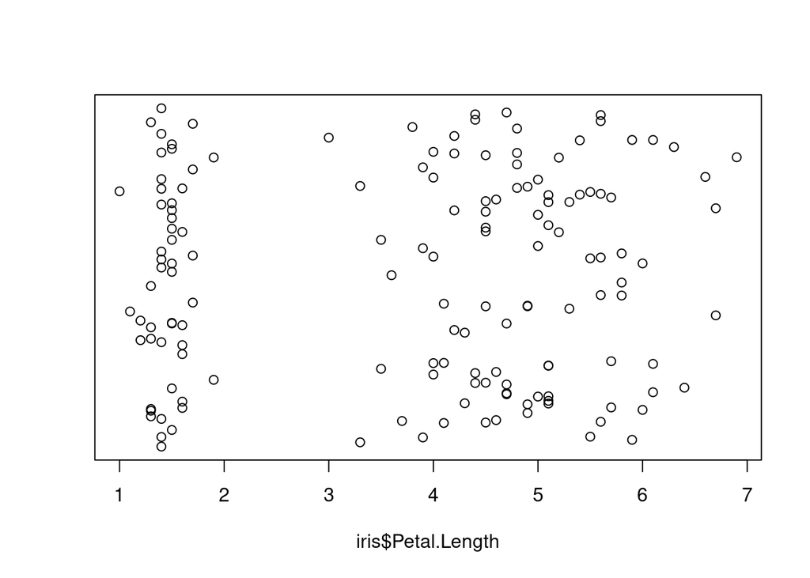

```r
plot(iris$Petal.Length, jitter(rep(1, nrow(iris))), ylab ="", yaxt = "n")
```

Histograms work better

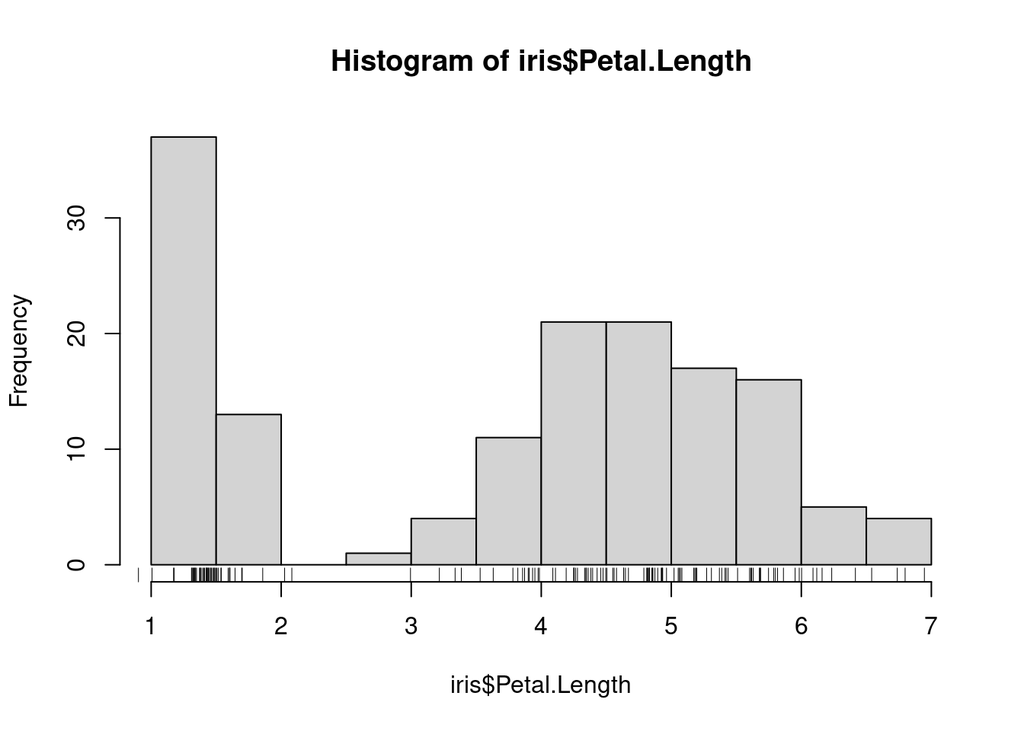

```r
hist(iris$Petal.Length)
rug(jitter(iris$Petal.Length, factor = 10))
```

We add jitter to the rug to prevent overplotting

We can also add a kernel density estimate KDE (red line)

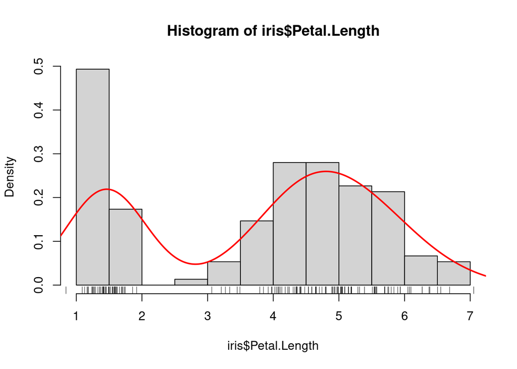

```r
hist(iris$Petal.Length, freq=FALSE)
rug(jitter(iris$Petal.Length, factor = 10))
lines(density(iris$Petal.Length), col="red", lwd = 2)
```

Plot 2d kernel density estimate

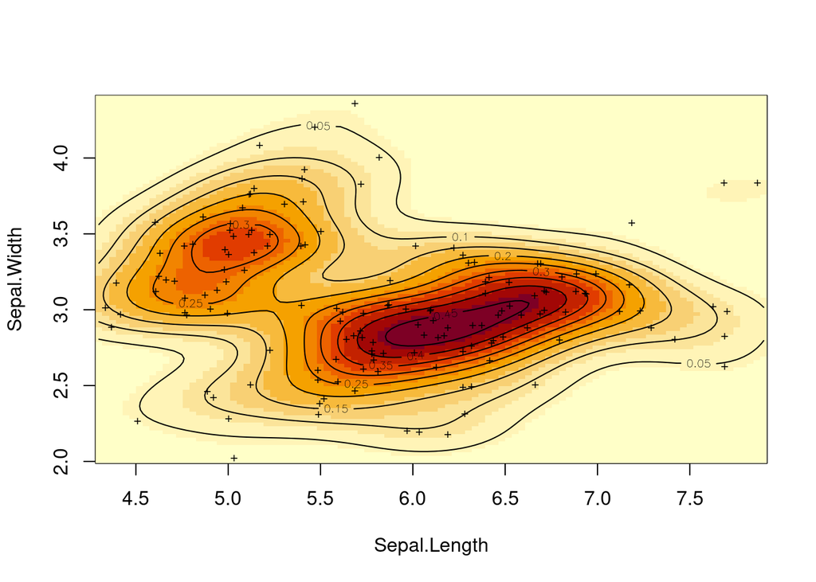

```r
library(MASS)
dens <- kde2d(iris$Sepal.Length, iris$Sepal.Width, n=100)

image(dens,
    xlab="Sepal.Length", ylab="Sepal.Width")
contour(dens, add=TRUE)
points(jitter(iris$Sepal.Length, 2), jitter(iris$Sepal.Width, 2),
  cex=.7, pch="+")
```

Use a 3d plot instead

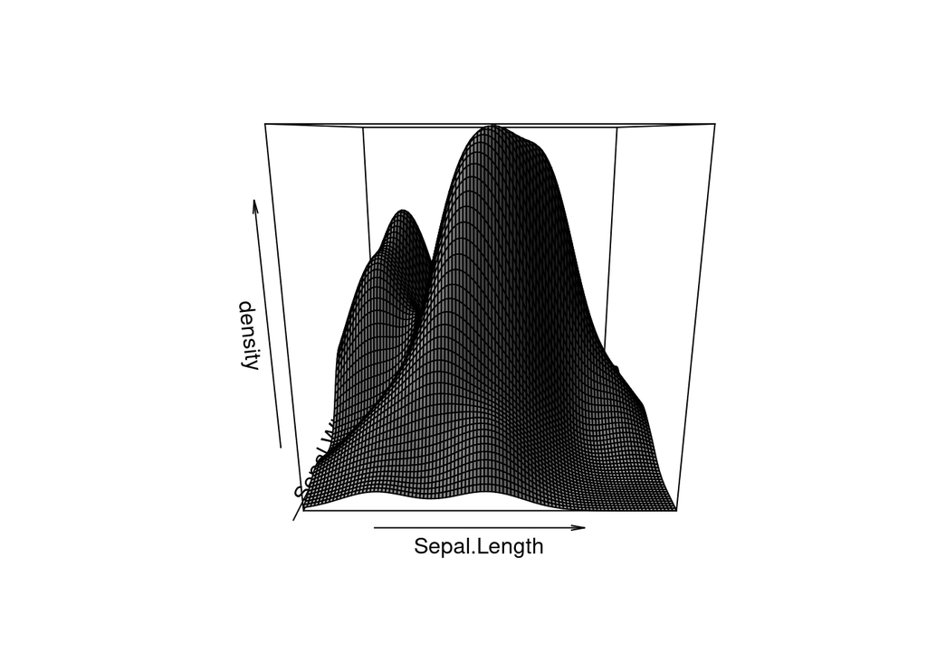

```r
persp(dens, xlab="Sepal.Length", ylab="Sepal.Width", zlab="density",
  shade=.5)
```